# mbquartR: An R Package for Working with Manitoba Quarter Sections

[alexkoiter.ca](https://alexkoiter.ca/)  
koitera@brandonu.ca  
alex-koiter  
[Alex-Koiter](https://www.linkedin.com/in/alex-koiter-43b04b2a8/)

[figure not shown]

[Visit the mbquartR website](https://docs.ropensci.org/mbquartR/)

Alex Koiter

Brandon University

## What is a quarter section?

- Land unit measuring 160 acres (~64.8 ha), representing a quarter of a square mile
- Originates from the Dominion Land Survey system
  - European settlement and colonization of Western Canada
- Explains why most farms are square!

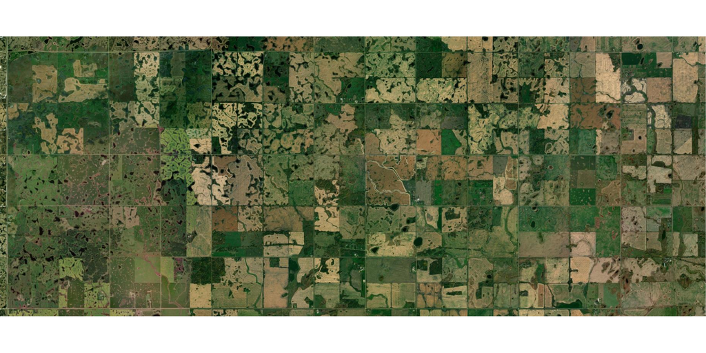

ESRI imagery

## What is a quarter section?

- A legal land description for a quarter section consists of four values separated by a “-”
1. Quarter Section (SW)
2. Section (9)
3. Township (8)
4. Range (6E1)
- **SW-9-8-6E1**: Southwest Quarter of Section 9, Township 8, Range 6 East of the 1st Meridian

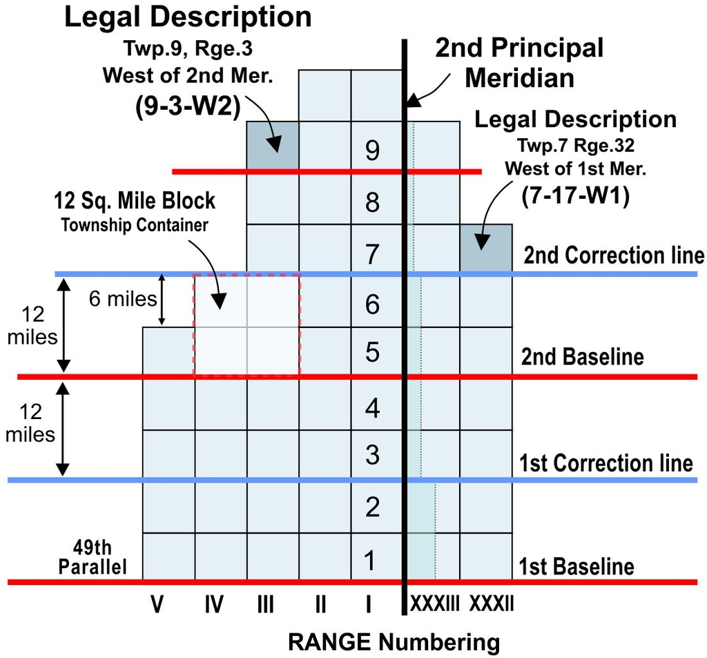

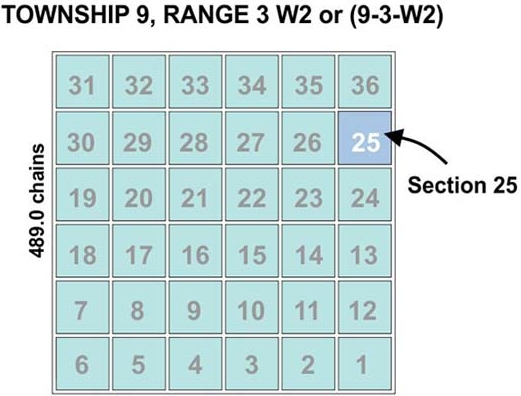

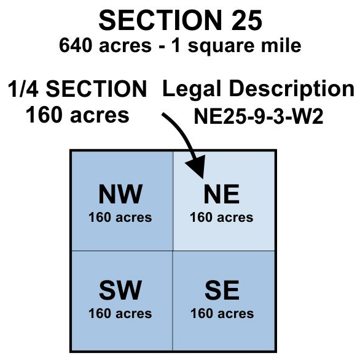

[kalmakov.com](https://kalmakov.com/historical/dominion%20land%20survey.html)

## Why are they used?

- Commonly used as a georeference before the widespread use of GPS
  - Archived samples and data
- Still commonly used in rural areas
  - A bit like a street address

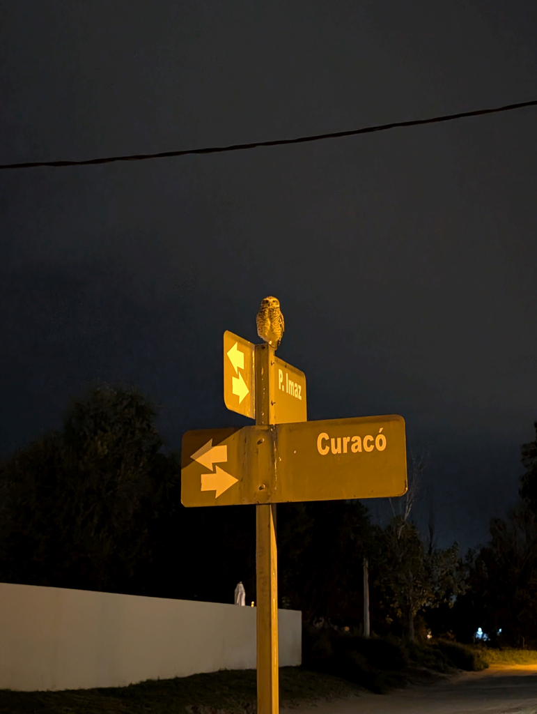

## Why are they difficult to use?

- Lack of familiarity with the system
- Google Maps can’t find SW-9-8-6E1 so I don’t know how to get there!
- Online resources do exist to locate to help find them
  - Fee based
  - No batch processing
  - Do not provide coordinates
  - Can not search by coordinates

[figure not shown]

## How it all started

- An email

**Dr. Steve Crittenden:**

Hi Alex,

I need to locate coordinates for a bunch of quarter sections.

There must be an R package for this, right?

- But there wasn’t! I was surprised and wanted to help

## How it all started

- Data was publicly available through [Data MB](https://geoportal.gov.mb.ca/)
1. Wrote a script that downloaded the database and searched the database

[figure not shown]

## How it all started

- Data was publicly available through [Data MB](https://geoportal.gov.mb.ca/)
1. Wrote a script that downloaded the database and searched the database
2. Which turned into a series of functions
3. Ultimately into an R package

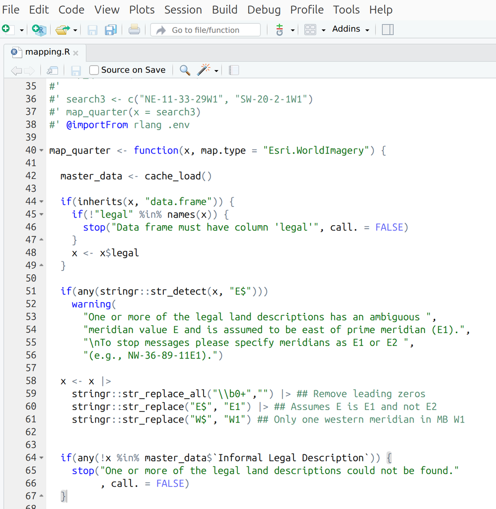

## Why use mbquartR?

### Free

- Free and open-source software (FOSS)

### Fast and Easy

- One line of code to download data
- One line of code to search
- One line of code to map

### Integrate into R work flows

- Coordinates can be used to link multiple datasets
- Working with older archived soil samples or data

## Why use mbquartR?

**Reproducible!**

- Scripts provide a record of actions
- Just note the `mbquartR` version
  - `packageVersion(mbquartR)`
- Hard to document mouse clicks or website searches

## mbquartR

### Installing mbquartR

```r
install.packages("mbquartR", repos = "https://ropensci.r-universe.dev")
```

- Available through the R-universe

[figure not shown]

## mbquartR

### Downloading the data

```r
quarters_dl()
```

- Downloads the data from Data MB
  - If website is not available it downloads an archived version
  - Data is not likely to change over time
  - More than **900,000** parcels of land!

[figure not shown]

## mbquartR

### Search by legal name

```r
search_legal(x = c("NE-11-33-29W", "SW-20-2-1E"))
```

### Output

```
# A tibble: 2 × 4
  legal         type      long   lat
  <chr>         <chr>    <dbl> <dbl>
1 NE-11-33-29W1 Quarter -101.   51.8
2 SW-20-2-1E1   Quarter  -97.4  49.1
```

- Spelling and order matters
- You can include leading zeroes (e.g., NE-01-012-12E1) or not (e.g., NE-1-12-12E1)
- Unless you specify it assumes you are using the E1 meridian not E2

## mbquartR

### Search by coordinates

```r
search_coord(long = c(-101.4656, -99.99768), lat = c(51.81913, 49.928926))
```

### Output

```
# A tibble: 2 × 7
  legal         type     long   lat long_user lat_user  dist
  <chr>         <chr>   <dbl> <dbl>     <dbl>    <dbl>   [m]
1 NE-11-33-29W1 Quarter -101.  51.8     -101.     51.8  29.9
2 NW-15-11-19W1 Quarter -100.  49.9     -100.     49.9 211.
```

## mbquartR

### Mapping

```r
map_quarter(x = c("NE-11-33-29W1", "SW-20-2-1W1"), map.type = "Esri.WorldImagery")
```

### Output

```
Polygons for quarter sections are approximate and are only meant as
    a visual aid.
```

[interactive chart not shown]

## mbquartR

### Documentation

- All functions have help documentation

```r
?map_quarter()
```

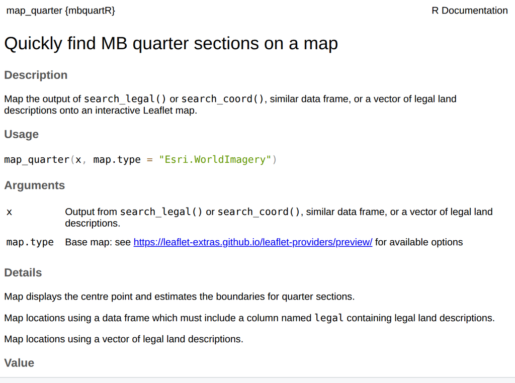

## mbquartR

### Documentation

- [Website](https://docs.ropensci.org/mbquartR/index.html)
  - [Vingnettes](https://docs.ropensci.org/mbquartR/articles/mbquartR.html)
  - [Examples](https://docs.ropensci.org/mbquartR/articles/example.html)

[figure not shown]

## Package development

- Lots of great online resources
  - [R Packages (2e)](https://r-pkgs.org/)
  - [Happy Git and GitHub for the useR](https://happygitwithr.com/)
  - [rOpenSci Dev Guide](https://devguide.ropensci.org/)
- Fantastic developer tools/packages
  - [`usethis`](https://usethis.r-lib.org/)
  - [`testthat`](https://testthat.r-lib.org/)
  - [`covr`](https://covr.r-lib.org/)

[figure not shown]

Hadley Wickham and Jennifer Bryan

## Package development

- Asked for lots of help along the way (thanks Steffi!)
- Looked at other examples (open source is awesome!)
- Tried really hard to break the package and anticipate unusual usage
- Helpful messages, warnings, and errors
- Useful package documentation

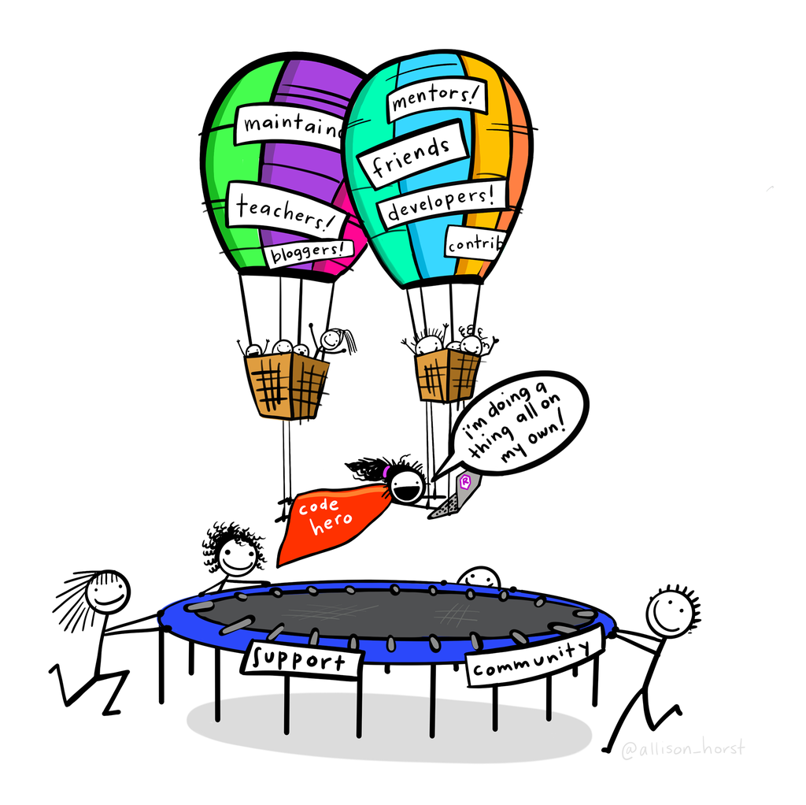

[Allison Horst](https://allisonhorst.com)

### I learned a lot throughout this process!

## rOpenSci Software Review

- The goal of the review is to improve the quality, reliability, and maintainability of scientific R packages
- Entire process is open and transparent ([my review](https://github.com/ropensci/software-review/issues/658))
- [Code of conduct](https://ropensci.org/code-of-conduct/) ensured a nice experience
- Pre-Submission Enquiry
  - Avoids putting in the work only to get a desk rejection
- Easy to follow [guidelines](https://devguide.ropensci.org/)

[figure not shown]

## rOpenSci Software Review

[figure not shown]

- My reviewers had excellent suggestions
- I was able to have a back and forth conversation with the reviewers
- Blog post about my experience ([English](https://ropensci.org/blog/2025/03/25/r-package-review/) / [Español](https://ropensci.org/es/blog/2025/03/25/r-package-review/))
- Once accepted, online code was transferred to rOpenSci
- I retain authorship and ownership
  - rOpenSci continues to provide support

## Want to contribute?

- Open an issue on the [mbquartR repository](https://github.com/ropensci/mbquartR)
  - Report a bug
  - Request a feature
  - Ask a question

[figure not shown]

## Want to contribute?

- Open an issue on the [mbquartR repository](https://github.com/ropensci/mbquartR)
  - Report a bug
  - Request a feature
  - Ask a question
- Read the [contributing guide](https://docs.ropensci.org/mbquartR/CONTRIBUTING.html)
  - Bug fixes
  - Feature implementation

[figure not shown]

## mbquartR: Finding MB quarter sections made easier!

**Want to learn more?**

[figure not shown]

[**alexkoiter.ca**](https://alexkoiter.ca)  
**koitera@brandonu.ca**  
[**alex-koiter**](https://github.com/alex-koiter)  
[**alex-koiter**](https://bsky.app/profile/alex-koiter.bsky.social)  
[**@alex_koiter@mstdn.ca**](https://mstdn.ca/@Alex_Koiter)  
[**Alex-Koiter**](https://www.linkedin.com/in/alex-koiter-43b04b2a8/)  
[**@alex_koiter**](https://twitter.com/alex_koiter)

*Slides created with [Quarto](https://quarto.org)*  
Updated 2026-02-03